# Test a Perceptual Phenomenon

### Analyzing the Stroop Effect

Perform the analysis in the space below. Remember to follow [the instructions](https://docs.google.com/document/d/1-OkpZLjG_kX9J6LIQ5IltsqMzVWjh36QpnP2RYpVdPU/pub?embedded=True) and review the [project rubric](https://review.udacity.com/#!/rubrics/71/view) before submitting. Once you've completed the analysis and write up, download this file as a PDF or HTML file and submit in the next section.

(1) What is the independent variable? What is the dependent variable?

The independent variable is the words condition (congruent or incongruent); The dedependent variale is the time to name the ink color.

(2) What is an appropriate set of hypotheses for this task? What kind of statistical test do you expect to perform? Justify your choices.

Null hypothesis: there is no difference between the time participants used to name the ink color under congruent and incongruent words condition;  
Alternative hypothesis: there is a significant difference between the time participants used to name the ink color under congruent and incongruent words condition.

I will use the paired t-test since the dependent variable is continuous which we assume are normally distributed. Each participant was tested twice and we are comparing the mean between two conditions.

(3) Report some descriptive statistics regarding this dataset. Include at least one measure of central tendency and at least one measure of variability. The name of the data file is 'stroopdata.csv'.

```python
import pandas as pd
stroop = pd.read_csv('stroopdata.csv')
stroop_mean = stroop.mean()
print('mean:', stroop_mean)
stroop_median = stroop.median()
print('median:', stroop_median)
stroop_var = stroop.var()
print('variance:', stroop_var)
stroop_std = stroop.std()
print('standard deviation:', stroop_std)
```

```
mean: Congruent      14.051125
Incongruent    22.015917
dtype: float64
median: Congruent      14.3565
Incongruent    21.0175
dtype: float64
variance: Congruent      12.669029
Incongruent    23.011757
dtype: float64
standard deviation: Congruent      3.559358
Incongruent    4.797057
dtype: float64
```

mean: Congruent 14.051125; Incongruent 22.015917

median: Congruent 14.3565; Incongruent 21.0175

variance: Congruent 12.669029; Incongruent 23.011757

standard deviation: Congruent 3.559358; Incongruent 4.797057

(4) Provide one or two visualizations that show the distribution of the sample data. Write one or two sentences noting what you observe about the plot or plots.

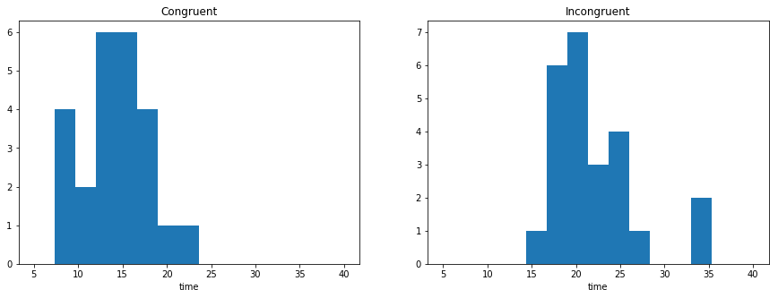

```python
import matplotlib.pyplot as plt
fig = plt.figure(figsize = (15, 5))
ax1 = fig.add_subplot(1,2,1)
ax2 = fig.add_subplot(1,2,2)

ax1.hist(stroop['Congruent'], bins = 15, range = (5,40))
ax1.set_title('Congruent')
ax1.set_xlabel('time')
ax2.hist(stroop['Incongruent'], bins = 15, range = (5,40))
ax2.set_title('Incongruent')
ax2.set_xlabel('time')
plt.show()
```

From the histogram, it looks like the time is approximately normally distributed and people took more time under incongruent words condition than congruent words condition.

(5) Now, perform the statistical test and report the results. What is the confidence level and your critical statistic value? Do you reject the null hypothesis or fail to reject it? Come to a conclusion in terms of the experiment task. Did the results match up with your expectations?

```python
from scipy.stats import ttest_rel
ttest_rel(stroop['Congruent'], stroop['Incongruent'])
```

```
Ttest_relResult(statistic=-8.020706944109957, pvalue=4.1030005857111781e-08)
```

confidence level = 0.95; t-statistic = -8.0207; p-value = 4.1030e-08.  
I reject the null hypothesis since p-value < 0.05.  
Conclusion: There is a significant difference between the time participants used to name the ink color under congruent and incongruent words condition.  
The results are what I expected since it is a lot harder to name the ink color when the words are saying other colors.